# Chelan-Douglas-Okanogan Monitoring Data

Processed on 2024-02-12 04:50:06 PST.

# Air Quality Monitors in 2020

*Disclaimer: Data presented here come from a variety of sources and do not represent official EPA measurements. Please visit [AirNow](https://www.airnow.gov) for official measurements.*

The Chelan-Douglas-Okanogan area had 11 monitor-deployments during the 2020 July - October wildfire season. These includes both regulatory monitors that are part of the EPA AQS system as well as “temporary” monitors deployed by state and federal agencies during wildfires.

This page provides an overview of monitoring data available in the USFS AirFire archives. Additional monitoring data may be available from state and tribal agencies.

Click on a dot in the map below to learn more about each monitor-deployment.

[interactive chart not shown]

## Hourly data

By plotting hourly measurements for all monitors at once, we can do a quick visual QC of available data. Clusters of points around a very high value may signal problems with a monitor and would require additional investigation to identify the sensor and assess the quality of that data.

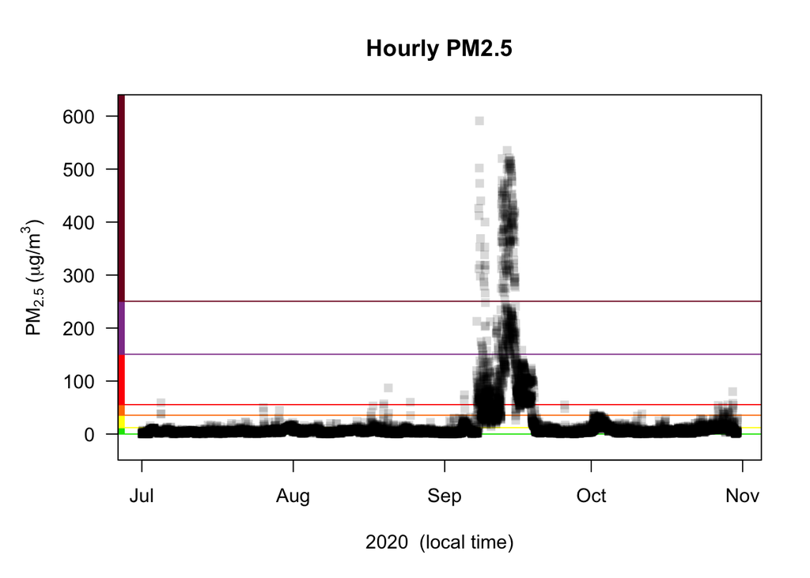

## Daily averages

Here, we plot daily averages for all monitors with enough data for this calculation. Some temporary monitors may not have enough valid data points per day and will be omitted from the plots below.

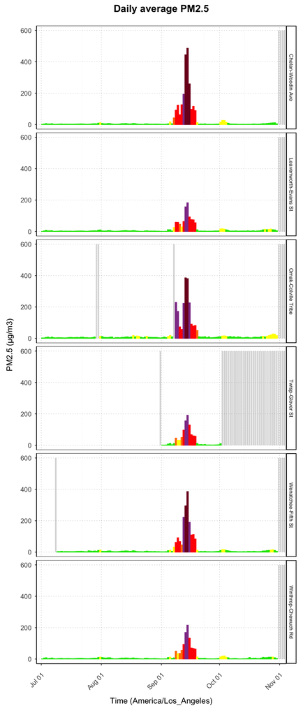